# Question

In a deck of strange cards, there are 229 cards. Each card has an image and a color.

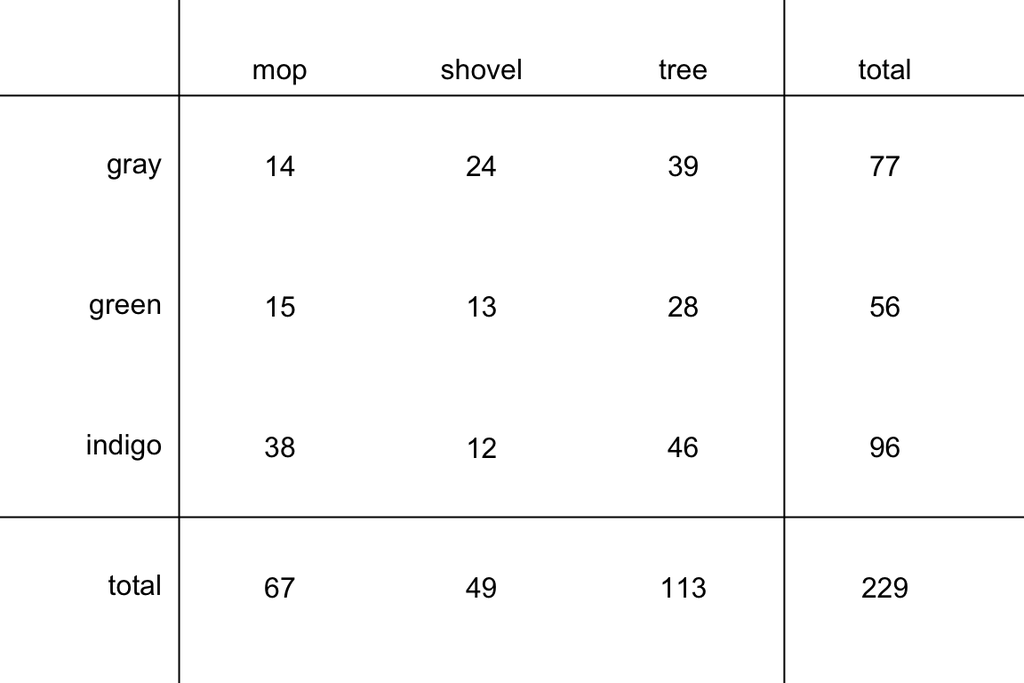

(Answers can be rounded to nearest hundredth.)

1. What is the probability a random card is a shovel? ##ANSWER1##
2. What is the probability a random card is green? ##ANSWER2##
3. What is the probability a random card is both a tree and indigo? ##ANSWER3##
4. What is the probability a random card is either a mop or gray (or both)? ##ANSWER4##
5. What is the probability a random card is gray given it is a tree? ##ANSWER5##
6. What is the probability a random card is a tree given it is green? ##ANSWER6##
7. Between a shovel and a tree, which is more likely to be a gray? ##ANSWER7##

## Answerlist

- 0.01
- 0.21
- 0.40
- 0.61
- 0.24
- 0.67
- 0.79
- 0.83
- 0.01
- 0.04
- 0.09
- 0.20
- 0.33
- 0.44
- 0.57
- 0.78
- 0.13
- 0.35
- 0.52
- 0.57
- 0.07
- 0.30
- 0.50
- 0.83
- A shovel.
- A tree.

# Solution

[video](https://vimeo.com/531915456)

The key logical terms are “[and](https://en.wikipedia.org/wiki/Logical_conjunction)”, “[or](https://en.wikipedia.org/wiki/Logical_disjunction)”, and “[given](https://en.wikipedia.org/wiki/Conditional_probability)”. Notice that I am using “given” as a shorter version of “under the condition”.

## Answerlist

- $\mathbb{P}[\text{shovel}]=\frac{49}{229}=0.21$
- $\mathbb{P}[\text{green}]=\frac{56}{229}=0.24$
- $\mathbb{P}[\text{tree and indigo}]=\frac{46}{229}=0.2$
- $\mathbb{P}[\text{mop or gray}]=\frac{67+77-14}{229}=0.57$
- $\mathbb{P}[\text{gray given tree}]=\frac{39}{113}=0.35$
- $\mathbb{P}[\text{tree given green}]=\frac{28}{56}=0.5$
- $\mathbb{P}[\text{gray given shovel}] = 0.49$ and $\mathbb{P}[\text{gray given tree}] = 0.35$, so a shovel is more likely to be gray than a tree is.
- .

# Meta-information

extype: cloze exsolution: 0100|1000|0001|0010|0100|0010|10 exclozetype: schoice|schoice|schoice|schoice|schoice|schoice|schoice exname: Cards_probabilities extol: 0.01 exextra[numwidth,logical]: TRUE